# Estadística Descriptiva

La clase pasada vimos los distintos tipos de variables —cualitativas o cuantitativas—, así como las diferentes escalas de medición en la que variables de dichos tipos pueden presentarse: la escala nominal y escala ordinal en el primer caso; la escala de intervalo y la escala de razón en el segundo; y la escala cíclica cuando tenemos variables ordinales o de intervalo.

En este documento revisaremos un conjunto de datos reales para ejemplificar los tipos de variables y escalas de medición, y presentaremos algunas alternativas más comunes para el análisis exploratorio de los datos.

# Descripción de la base de datos

```r
library('tidyverse')
library('nycflights13')
```

# Análisis exploratorio

## Estructura de la base de datos

```r
data(flights)     # cargamos a BBDD
dim(flights)      # dimensiones
```

```
## [1] 336776     19
```

```r
str(flights)      # resumen de la estructura de la BBDD
```

```
## tibble [336,776 x 19] (S3: tbl_df/tbl/data.frame)
##  $ year          : int [1:336776] 2013 2013 2013 2013 2013 2013 2013 2013 2013 2013 ...
##  $ month         : int [1:336776] 1 1 1 1 1 1 1 1 1 1 ...
##  $ day           : int [1:336776] 1 1 1 1 1 1 1 1 1 1 ...
##  $ dep_time      : int [1:336776] 517 533 542 544 554 554 555 557 557 558 ...
##  $ sched_dep_time: int [1:336776] 515 529 540 545 600 558 600 600 600 600 ...
##  $ dep_delay     : num [1:336776] 2 4 2 -1 -6 -4 -5 -3 -3 -2 ...
##  $ arr_time      : int [1:336776] 830 850 923 1004 812 740 913 709 838 753 ...
##  $ sched_arr_time: int [1:336776] 819 830 850 1022 837 728 854 723 846 745 ...
##  $ arr_delay     : num [1:336776] 11 20 33 -18 -25 12 19 -14 -8 8 ...
##  $ carrier       : chr [1:336776] "UA" "UA" "AA" "B6" ...
##  $ flight        : int [1:336776] 1545 1714 1141 725 461 1696 507 5708 79 301 ...
##  $ tailnum       : chr [1:336776] "N14228" "N24211" "N619AA" "N804JB" ...
##  $ origin        : chr [1:336776] "EWR" "LGA" "JFK" "JFK" ...
##  $ dest          : chr [1:336776] "IAH" "IAH" "MIA" "BQN" ...
##  $ air_time      : num [1:336776] 227 227 160 183 116 150 158 53 140 138 ...
##  $ distance      : num [1:336776] 1400 1416 1089 1576 762 ...
##  $ hour          : num [1:336776] 5 5 5 5 6 5 6 6 6 6 ...
##  $ minute        : num [1:336776] 15 29 40 45 0 58 0 0 0 0 ...
##  $ time_hour     : POSIXct[1:336776], format: "2013-01-01 05:00:00" "2013-01-01 05:00:00" ...
```

```r
head(flights, 10)     # vistazo de las primeras 10 líneas de la BBDD
```

```
## # A tibble: 10 x 19
##     year month   day dep_time sched_dep_time dep_delay arr_time sched_arr_time
##    <int> <int> <int>    <int>          <int>     <dbl>    <int>          <int>
##  1  2013     1     1      517            515         2      830            819
##  2  2013     1     1      533            529         4      850            830
##  3  2013     1     1      542            540         2      923            850
##  4  2013     1     1      544            545        -1     1004           1022
##  5  2013     1     1      554            600        -6      812            837
##  6  2013     1     1      554            558        -4      740            728
##  7  2013     1     1      555            600        -5      913            854
##  8  2013     1     1      557            600        -3      709            723
##  9  2013     1     1      557            600        -3      838            846
## 10  2013     1     1      558            600        -2      753            745
## # ... with 11 more variables: arr_delay <dbl>, carrier <chr>, flight <int>,
## #   tailnum <chr>, origin <chr>, dest <chr>, air_time <dbl>, distance <dbl>,
## #   hour <dbl>, minute <dbl>, time_hour <dttm>
```

```r
summary(flights)  # resumen de las variables
```

```
##       year          month             day           dep_time    sched_dep_time
##  Min.   :2013   Min.   : 1.000   Min.   : 1.00   Min.   :   1   Min.   : 106
##  1st Qu.:2013   1st Qu.: 4.000   1st Qu.: 8.00   1st Qu.: 907   1st Qu.: 906
##  Median :2013   Median : 7.000   Median :16.00   Median :1401   Median :1359
##  Mean   :2013   Mean   : 6.549   Mean   :15.71   Mean   :1349   Mean   :1344
##  3rd Qu.:2013   3rd Qu.:10.000   3rd Qu.:23.00   3rd Qu.:1744   3rd Qu.:1729
##  Max.   :2013   Max.   :12.000   Max.   :31.00   Max.   :2400   Max.   :2359
##                                                  NA's   :8255
##    dep_delay          arr_time    sched_arr_time   arr_delay
##  Min.   : -43.00   Min.   :   1   Min.   :   1   Min.   : -86.000
##  1st Qu.:  -5.00   1st Qu.:1104   1st Qu.:1124   1st Qu.: -17.000
##  Median :  -2.00   Median :1535   Median :1556   Median :  -5.000
##  Mean   :  12.64   Mean   :1502   Mean   :1536   Mean   :   6.895
##  3rd Qu.:  11.00   3rd Qu.:1940   3rd Qu.:1945   3rd Qu.:  14.000
##  Max.   :1301.00   Max.   :2400   Max.   :2359   Max.   :1272.000
##  NA's   :8255      NA's   :8713                  NA's   :9430
##    carrier              flight       tailnum             origin
##  Length:336776      Min.   :   1   Length:336776      Length:336776
##  Class :character   1st Qu.: 553   Class :character   Class :character
##  Mode  :character   Median :1496   Mode  :character   Mode  :character
##                     Mean   :1972
##                     3rd Qu.:3465
##                     Max.   :8500
##
##      dest              air_time        distance         hour
##  Length:336776      Min.   : 20.0   Min.   :  17   Min.   : 1.00
##  Class :character   1st Qu.: 82.0   1st Qu.: 502   1st Qu.: 9.00
##  Mode  :character   Median :129.0   Median : 872   Median :13.00
##                     Mean   :150.7   Mean   :1040   Mean   :13.18
##                     3rd Qu.:192.0   3rd Qu.:1389   3rd Qu.:17.00
##                     Max.   :695.0   Max.   :4983   Max.   :23.00
##                     NA's   :9430
##      minute        time_hour
##  Min.   : 0.00   Min.   :2013-01-01 05:00:00
##  1st Qu.: 8.00   1st Qu.:2013-04-04 13:00:00
##  Median :29.00   Median :2013-07-03 10:00:00
##  Mean   :26.23   Mean   :2013-07-03 05:22:54
##  3rd Qu.:44.00   3rd Qu.:2013-10-01 07:00:00
##  Max.   :59.00   Max.   :2013-12-31 23:00:00
##
```

## Variables cualitativas

### Distribución de frecuencias

Las distribuciones de frecuencias son una herramienta muy útil que permite entender el comportamiento distribucional de nuestros datos, sin importar si estos son cualitativos o cuantitativos.

Las distribuciones de frecuencias no son más que tablas compuestas por las diferentes categorías en el caso de variables cualitativas o intervalos en el caso de variables cualitativas, y la frecuencia (incidencia) de cada uno de estos valores en la muestra observada de los datos.

Las distribuciones de frecuencias son la base de algunos métodos gráficos como los diagramas de barra, o de los histogramas en el caso de variables cuantitativas.

En el caso de las varaibles cualitativas, las distribuciones de frecuencias se presentan en forma de tablas compuestas por las diferentes categorías y sus respectivos niveles, indicando las frecuencias o incidencias de cada uno en la muestra observada de los datos.

Las distribuciones de frecuencias son la base de algunos métodos gráficos como los diagramas de barras y otros derivados.

```r
flights %>% count(origin)
```

```
## # A tibble: 3 x 2
##   origin      n
##   <chr>   <int>
## 1 EWR    120835
## 2 JFK    111279
## 3 LGA    104662
```

Puede resultar útil conocer la distribución de frecuencias *relativas*: el porcentaje del total que cada nivel representa. Además, conviene ordenar los datos de forma que se facilite la lectura o interpretación.

```r
flights %>% count(origin) %>%
  mutate(porcentaje = n / sum(n) * 100) %>%
  arrange(-n)
```

```
## # A tibble: 3 x 3
##   origin      n porcentaje
##   <chr>   <int>      <dbl>
## 1 EWR    120835       35.9
## 2 JFK    111279       33.0
## 3 LGA    104662       31.1
```

```r
flights %>% count(dest) %>%
  mutate(porcentaje = n / sum(n) * 100) %>%
  arrange(-n)
```

```
## # A tibble: 105 x 3
##    dest      n porcentaje
##    <chr> <int>      <dbl>
##  1 ORD   17283       5.13
##  2 ATL   17215       5.11
##  3 LAX   16174       4.80
##  4 BOS   15508       4.60
##  5 MCO   14082       4.18
##  6 CLT   14064       4.18
##  7 SFO   13331       3.96
##  8 FLL   12055       3.58
##  9 MIA   11728       3.48
## 10 DCA    9705       2.88
## # ... with 95 more rows
```

### Diagramas de barras

A partir de las distribuciones de frecuencias, es posible presentar los resultados de manera gráfica mediante un diagrama de barras, el cual nos ayuda a visualizar de mejor manera los resultados obtenidos.

Los diagramas de barras son gráficos que contienen tantas barras como categorías en la variable. Estas barras son del mismo ancho, pero su altura depende de la frecuencia (absoluta o relativa) registrada.

Existen varias buenas prácticas a la hora de presentar este tipo de gráficas —en realidad no sólo en este caso: siempre vale la pena cuestionarse si es posible hacer cambios que faciliten el entendimiento e interpretabilidad de las gráficas—. Por ejemplo, es importante que, en caso de que se opte por frecuencias relativas, siempre se especifique el tamaño de la muestra que representan esos porcentajes. También es buena idea ordenar las categorías de mayor a menor frecuencia.

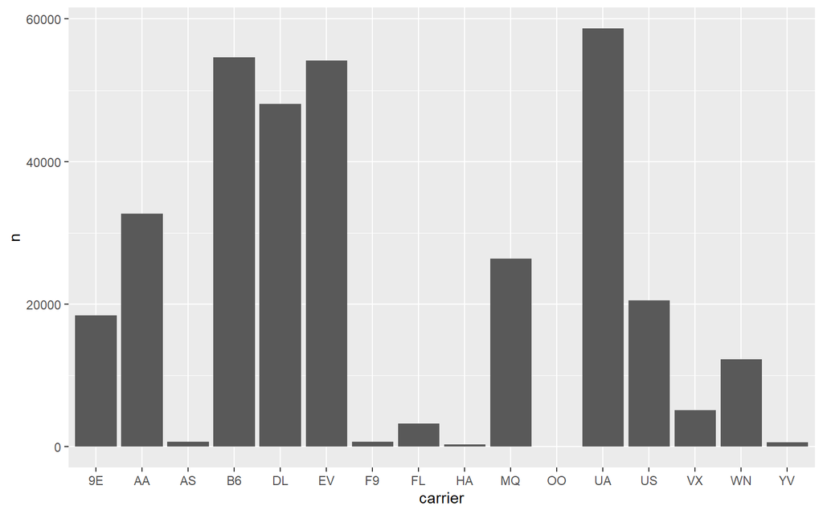

```r
flights %>%
  count(carrier) %>%
  arrange(n) %>%
  ggplot(aes(carrier, n)) +
  geom_col()
```

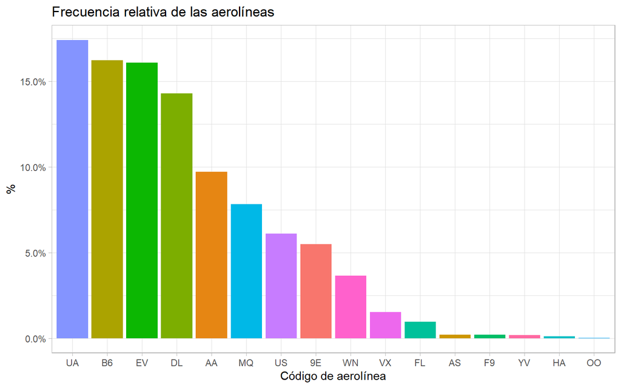

```r
flights %>%
  count(carrier) %>%
  mutate(p = n / sum(n)) %>%
  ggplot(aes(reorder(carrier, -p), p, fill = carrier)) +
  geom_col() +
  scale_y_continuous(labels = scales::percent) +
  labs(x = 'Código de aerolínea', y = '%',
       title = 'Frecuencia relativa de las aerolíneas') +
  theme_light() +
  theme(legend.position = 'none')
```

### Diagramas circulares

Otra forma de representar los distribuciones de frecuencias de datos cualitativos es mediante gráficas circulares o ‘’de pay’’. En este tipo de diagramas se utilizan únicamente las frecuencias relativas y son muy populares para enfatizar el hecho de que las clases o categorías corresponden o forman parte de un todo.

Sin embargo, los diagramas circulares en muchas ocasiones pueden ser más confusos y poco informativos y perjudicar más de lo que realmente ayudan, particularmente si se tienen muchas clases o si están muy pulverizadas las categorías.

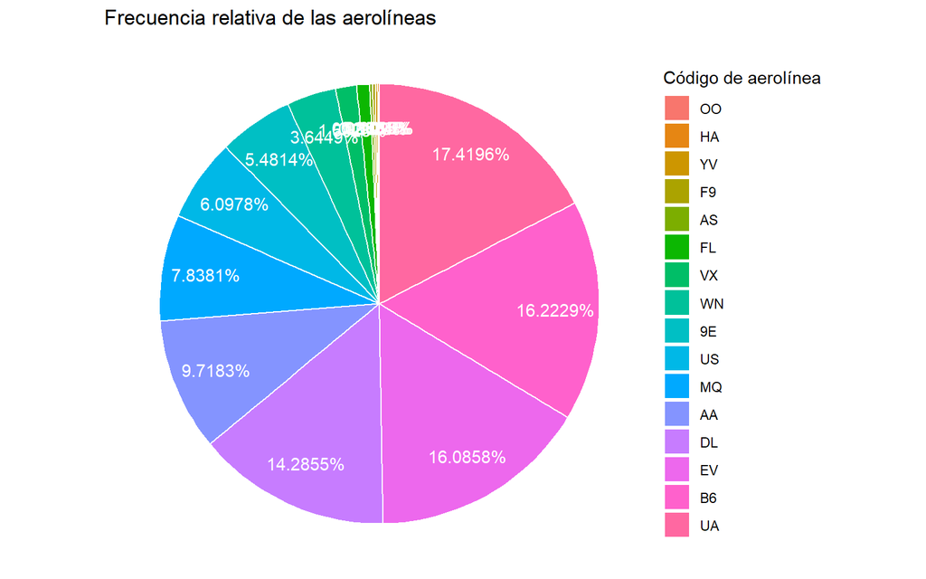

```r
flights %>%
  count(carrier) %>%
  mutate(p = 100*n / sum(n)) %>%
  arrange(-n) %>%
  mutate(carrier = factor(carrier, levels = rev(.$carrier)),
         ypos = cumsum(p) - 0.5*p) %>%
  ggplot(aes(x = '', p, fill = carrier)) +
  geom_bar(stat = "identity", width = 1, color = "white") +
  geom_text(aes(x=1.3,y = ypos, label = scales::percent(p/100)), color = "white") +
  labs(title = 'Frecuencia relativa de las aerolíneas', fill = 'Código de aerolínea') +
  coord_polar("y", start = 0) +
  theme_void()
```

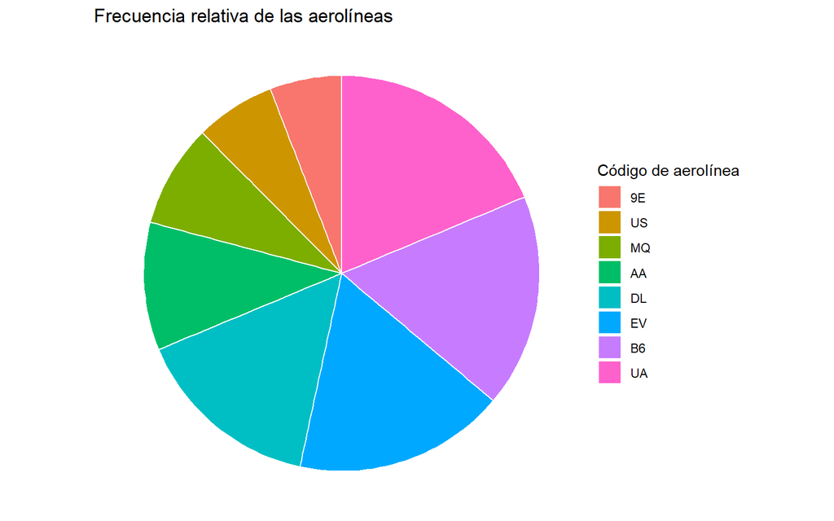

```r
flights %>%
  count(carrier) %>%
  top_n(8, n) %>%
  mutate(p = 100*n / sum(n)) %>%
  arrange(-n) %>%
  mutate(carrier = factor(carrier, levels = rev(.$carrier)),
         ypos = cumsum(p) - 0.5*p) %>%
  ggplot(aes(x = '', p, fill = carrier)) +
  geom_bar(stat = "identity", width = 1, color = "white") +
  labs(title = 'Frecuencia relativa de las aerolíneas', fill = 'Código de aerolínea') +
  coord_polar("y", start = 0) +
  theme_void()
```

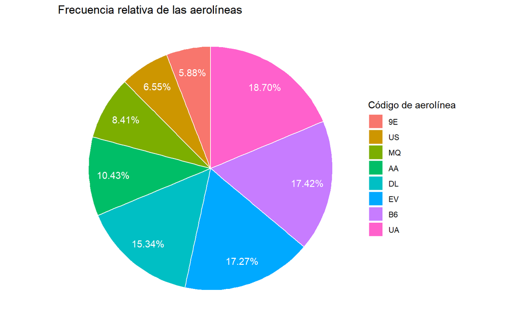

```r
flights %>%
  count(carrier) %>%
  top_n(8, n) %>%
  mutate(p = 100*n / sum(n)) %>%
  arrange(-n) %>%
  mutate(carrier = factor(carrier, levels = rev(.$carrier)),
         ypos = cumsum(p) - 0.5*p) %>%
  ggplot(aes(x = '', p, fill = carrier)) +
  geom_bar(stat = "identity", width = 1, color = "white") +
  geom_text(aes(x=1.3,y = ypos, label = scales::percent(p/100)), color = "white") +
  labs(title = 'Frecuencia relativa de las aerolíneas', fill = 'Código de aerolínea') +
  coord_polar("y", start = 0) +
  theme_void()
```

> *OJO:* Por lo mencionado arriba, se recomienda evitar utilizar este tipo de diagramas.

## Variables cuantitativas

Recordemos que los datos cuantitativos pueden ser discretos o continuos, dependiendo del proceso con los que se obtuvieron (conteos o mediciones, respectivamente). A los datos discretos, pese a ser cuantitativos, para efectos del análisis exploratorio les daremos el mismo tratamiento que a los datos cualitativos.

Para esto, consideremos que los diferentes valores que puede tomar una variable discreta son equivalentes a las clases que toma una variable cualitativa. De esta manera igualmente se construyen distribuciones de frecuencias para los valores que toma la variable y la frecuencia con que estos se observan. Los diagramas de barras igualmente se calculan a partir de estas distribuciones de frecuencias.

Por el contrario, en el caso de datos continuos, el análisis exploratorio sí será diferente.

### Distribuciones de frecuencias

En el caso de datos continuos, debemos definir las clases o categorías de los datos, entendidas como intervalos ajenos y exhaustivos. Para esto, lo que hacemos es lo siguiente:

Hagamos el análisis para la variable `distance`:

1. Calculamos el rango:

```r
(x.min <- min(flights$distance))
```

```
## [1] 17
```

```r
(x.max <- max(flights$distance))
```

```
## [1] 4983
```

```r
(rango <- x.max - x.min)
```

```
## [1] 4966
```

2. Fijamos $k = 8$:

```r
k <- 8
```

3. El rango de valores de cadad subintervalo es
   $$RI = \frac{R(\underline{X})}{k} = \frac{4966}{8}=620.75 \approx 621$$

```r
rango.intervalos <- round(rango / (k))
```

4. Por último, establecemos las clases y calculamos frecuencias:

```r
cortes <- seq(x.min, x.max, length.out = k+1)

frecuencias <- data.frame(matrix(rep(cortes, each = 2)[-c(1,(2*k)+1)], ncol = 2, byrow = T)) %>%
  unite(intervalo, c('X1', 'X2'), sep = ' - ') %>%
  rownames_to_column('intervalo.dist') %>%
  mutate(intervalo.dist = as.numeric(intervalo.dist)) %>%
  left_join(flights %>%
              mutate(intervalo.dist = findInterval(distance, seq(x.min, x.max, rango.intervalos), rightmost.closed=F)) %>%
              count(intervalo.dist, .drop = F))
frecuencias[is.na(frecuencias)] <- 0
frecuencias
```

```
##   intervalo.dist        intervalo      n
## 1              1      17 - 637.75 110839
## 2              2  637.75 - 1258.5 134827
## 3              3 1258.5 - 1879.25  36910
## 4              4   1879.25 - 2500  39229
## 5              5   2500 - 3120.75  14256
## 6              6 3120.75 - 3741.5      8
## 7              7 3741.5 - 4362.25      0
## 8              8   4362.25 - 4983    707
```

### Histogramas

Los histogramas son la representación gráfica de las distribuciones de frecuencias de datos continuos. Son una forma particular de una gráfica de barras en el cual los intervalos de clase están en función del ancho de banda y las frecuencias son proporcionales a las áreas de los rectángulos.

Pueden calcularse para frecuencias absolutas o para frecuencias relativas. No obstante, los histogramas son, generalmente, más informativos cuando las frecuencias representadas son relativas, puesto que reflejan el porcentaje de ocurrencia en cada intervalo.

Son muy útiles para perfilar el comportamiento de la muestra, el cual se espera que sea semejante al de la población. Además, es una herramienta que nos permite determinar la variabilidad y distribución de los datos, el cual, como hemos dicho antes, es uno de los objetivos del análisis exploratorio de datos.

La distribución de frecuencias poblacional de una variable continua puede considerarse como una versión suavizada de un histograma que considera a toda la población. La representación gráfica de las frecuencias poblacionales es denominada curva de distribución y a partir de ella se pueden identificar las siguientes características:

- *Simetría*: Se dice que una distribución es simétrica si existe un valor central alrededor del cual los valores inferiores y superiores son igualmente probables.
- *Sesgo o asimetría*: Se dice que una distribución es asimétrica si una extremidad o cola de la distribución está más extendida que la otra.
- *Bimodalidad*: Se dice que una distribución es bimodal si posee dos cimas o jorobas separadas que indican la presencia de dos grupos diferentes en una población.

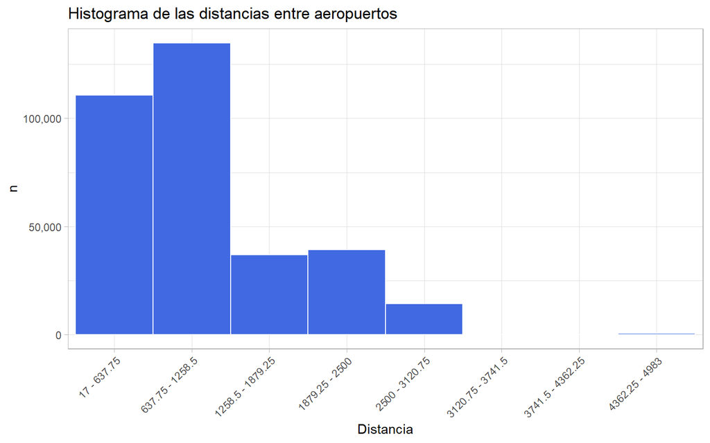

```r
frecuencias %>%
  ggplot(aes(reorder(intervalo, intervalo.dist), n)) +
  geom_col(fill = 'royal blue', color = 'white', width = 1) +
  scale_y_continuous(labels = scales::comma) +
  labs(x = 'Distancia', y = 'n',
       title = 'Histograma de las distancias entre aeropuertos') +
  theme_light() +
  theme(legend.position = 'none',
        axis.text.x = element_text(angle = 45, hjust = 1))
```

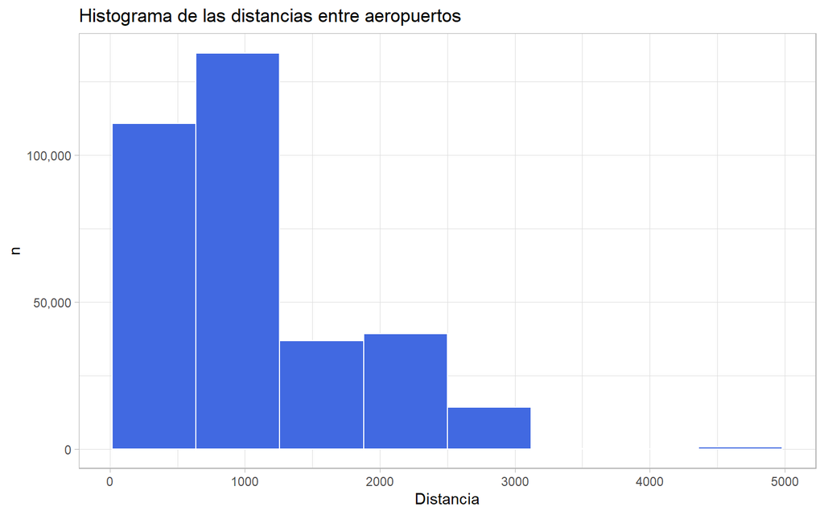

```r
flights %>%
  ggplot() +
  geom_histogram(aes(distance), fill = 'royal blue', color = 'white',
                 bins = k+1, boundary = 17) +
  scale_y_continuous(labels = scales::comma) +
  labs(x = 'Distancia', y = 'n',
       title = 'Histograma de las distancias entre aeropuertos') +
  theme_light()
```

### *Boxplots*

Los *boxplots*, también llamados en español *diagramas de caja y brazos* o *diagramas de caja y bigotes* resultan sumamente útiles para resumir las características más importantes de un conjunto de observaciones como

- localización
- dispersión
- simetría
- datos atípicos

También son excelentes herramientas para comparar dos o más conjuntos de datos.

**Se pueden construir de diferentes maneras**. En particular, la caja siempre se construirá siguiendo los mismos criterios que veremos más abajo, aunque los brazos pueden variar dependiendo de la versión de *boxplot* que se utilice.

La caja se construye mediante los cuartiles de la distribución: el extremo inferior es el primer cuartil, y el extremo superior, el tercero. La mediana (o segundo cuartil) siempre se marca al interior de la caja con una línea más gruesa que los extremos de la caja.

> *Nota:* En un *boxplot* no solemos especificar la media de la distribución. Por lo tanto, en un *boxplot* típico NO ES POSIBLE conocer la media de los datos.

Los brazos se pueden construir de diferentes maneras:

- Sumando y restando de cada extremo de la caja $1.5\cdot RI(\underline{X}) = 1.5(q_3-q_1)$
- Tomando como base el mínimo y máximo de los datos
- Sumando y restando una desviación estándar alrededor de la media de los datos
- Tomando los percentiles 9 y 91
- Tomando los percentiles 8 y 92

De los anteriores, el primer caso es la versión más común —y la conocemos como Boxplot de Tukey—. Sin embargo, dependiendo de cuánto varíen los datos, podemos elegir alguna otra de las alternativas.

Finalmente, todas las observaciones que se salgan de los brazos los consideraremos datos atípicos y serán representados por puntos.

Veamos dos ejemplos con los datos de `flights`.

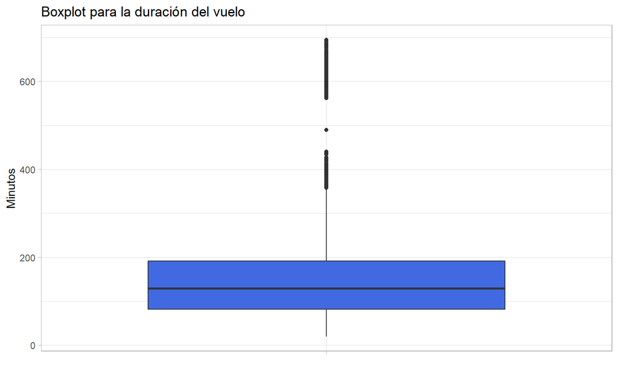

```r
flights %>%
  ggplot() +
  geom_boxplot(aes(x = '', y = air_time), fill = 'royal blue') +
  labs(x = '', y = 'Minutos',
       title = 'Boxplot para la duración del vuelo') +
  theme_light()
```

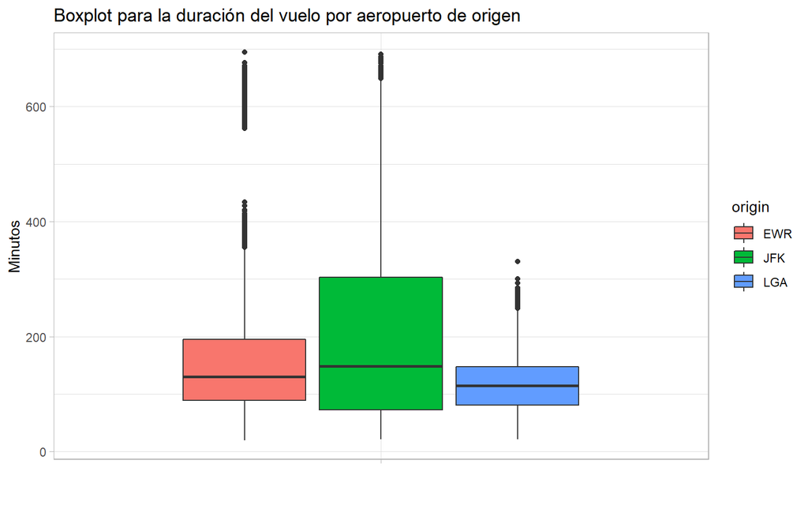

```r
flights %>%
  ggplot() +
  geom_boxplot(aes(x = '', y = air_time, fill = origin)) +
  labs(x = '', y = 'Minutos',
       title = 'Boxplot para la duración del vuelo por aeropuerto de origen') +
  theme_light()
```

## Análisis bivariado

### Diagramas de dispersión

Los diagramas de dispersión consisten en mostrar los valores de dos variables a la par en un plano cartesiano. Este gráfico puede resultar muy valioso por dos motivos: puede ayudar a apreciar la relación (lineal o no lineal) entre dos variables y, por otro lado, se presta para poder graficar no sólo dos dimensiones sino tres o hasta cuatro en un solo plano.

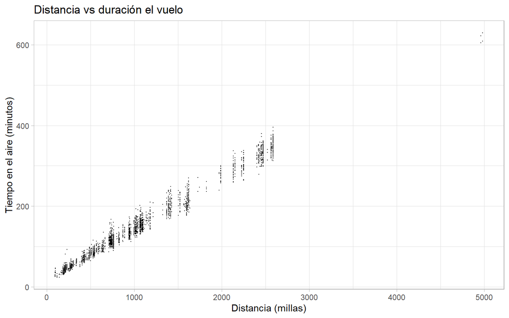

```r
flights %>%
  sample_n(3000) %>%
  ggplot() +
  geom_point(aes(distance, air_time), size = 0.1) +
  labs(x = 'Distancia (millas)', y = 'Tiempo en el aire (minutos)',
       title = 'Distancia vs duración el vuelo') +
  theme_light()
```

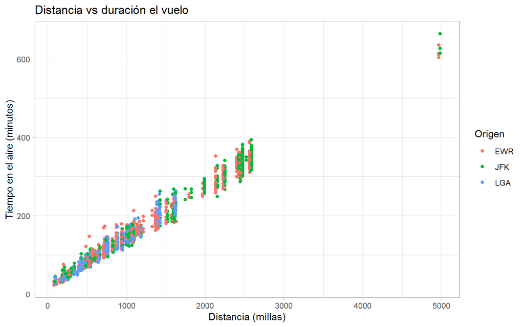

```r
flights %>%
  sample_n(3000) %>%
  ggplot() +
  geom_point(aes(distance, air_time, color = factor(origin))) +
  labs(x = 'Distancia (millas)', y = 'Tiempo en el aire (minutos)',
       title = 'Distancia vs duración el vuelo', color = 'Origen') +
  theme_light()
```

### Medidas de asociación lineal

En el análisis descriptivo, ante la presencia de varias variables, una pregunta que comúnmente nos hacemos es ¿qué tan relacionadas están dos variables? Cabe resaltar que las variables pueden estar asociadas de manera lineal o de manera no lineal; sin embargo, lo más común es buscar siempre asociaciones lineales entre las variables.

Se han propuesto numerosas métricas para determinas cuán asociadas (linealmente) están dos variables. Estas métricas se calculan dependiendo de la escala de medición de los datos. En la siguiente tabla se listan algunos de los casos más comunes:

| **Nombre de la métrica** | **Escala de la variable A** | **Escala de la variable B** |
| --- | --- | --- |
| V de Cramér | Nominal | Nominal |
| Coeficiente de correlación de Spearman | Ordinal | Ordinal |
| Tau de Kendall | Ordinal | Ordinal |
| Gamma de Kruskal | Ordinal | Ordinal |
| Phi de Pearson | Dicotómica | Dicotómica |
| Punto biserial | De intervalo | Dicotómica |
| Coeficiente de correlación de Pearson | De intervalo o de razón | De intervalo o de razón |

### Coeficiente de correlación de Pearson

Quizá la medida de asociación lineal quizá más utilizada (aunque también más errónameante utilizada) es el coeficiente de correlación de Pearson. Válido cuando las variables son de intervalo o de razón, nos permite cuantificar la fuerza y dirección de una relación lineal entre dos variables. Es importante resaltar que la correlación entre dos variables no implica, por sí misma, ninguna relación de causalidad.

El coeficiente de correlación de Pearson poblacional para dos variables aleatorias $X$ y $Y$ se define como:
$$\rho_{X,Y}=\frac{\sigma_{X,Y}}{\sigma_{X}\sigma_{Y}}$$

Mientras que el coeficiente de correlación muestral para dos variables aleatorias $X$ y $Y$ se define como:
$$r_{x,y}=\dfrac{\sum x_iy_i-n\bar{x}\bar{y}}{(n-1)s_xs_y}$$

Valores de $\rho$ cercanos a 1 indican una fuerte asociación en el mismo sentido (cuando una variable crece, la otra también lo hace). En contraste, valores de $\rho$ cercanos a -1 indican una fuerte asociación en sentidos opuestos (cuando una variable crece, la otra decrece). Finalmente, valores alrededor del cero indican que no hay una asociación **lineal** entre las variables.

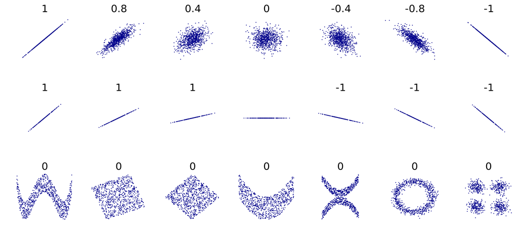

```r
flights %>%
  select(contains('delay'), air_time, distance, hour) %>%
  na.omit() %>%
  cor()
```

```
##             dep_delay   arr_delay    air_time    distance        hour
## dep_delay  1.00000000  0.91480276 -0.02240508 -0.02168090  0.19826915
## arr_delay  0.91480276  1.00000000 -0.03529709 -0.06186776  0.17345557
## air_time  -0.02240508 -0.03529709  1.00000000  0.99064965 -0.01627728
## distance  -0.02168090 -0.06186776  0.99064965  1.00000000 -0.01373050
## hour       0.19826915  0.17345557 -0.01627728 -0.01373050  1.00000000
```

### Otros ejemplos interesantes de medidas de asociación

#### V de Cramér

Como se menciona en la tabla de arriba, la $V$ de Cramér es una medida de asociación apta para dos variables *nominales*. La $V$ es un número entre $0$ y $1$; si es cercana a $0$, significa que la asociación es débil, si es cercano a $1$, la asociación es fuerte. Por ejemplo:

- ¿Será considerable la asociación entre las variables `carrier` y `dest`?
- ¿Será considerable la asociación entre las variables `origin` y `dest`?
- ¿Será considerable la asociación entre las variables `carrier` y `tailnum`?

```r
library('rcompanion')
cramerV(flights$carrier, flights$dest)
```

```
## Cramer V
##   0.5257
```

```r
cramerV(flights$origin, flights$dest)
```

```
## Cramer V
##   0.4374
```

```r
cramerV(flights$carrier, flights$tailnum)
```

```
## Cramer V
##    0.995
```

#### τ de Kendall

Esta métrica es un número entre $-1$ y $1$. Al igual que el coeficiente de correlación de Pearson, el signo indica la dirección de la asociación, y si su valor absoluto es cercano a $1$, la asociación es fuerte, mientras que si es cercano a $0$, la asociación es débil.

```r
library('VGAM')
library('magrittr')

flights %<>%
  mutate(estacion = case_when(month %in% 4:6 ~ 3,
                              month %in% 7:9 ~ 4,
                              month %in% 10:12 ~ 1,
                              month %in% 1:3 ~ 2))

cor(flights$estacion, flights$month)
```

```
## [1] -0.2010776
```

```r
kendall.tau(flights$estacion, flights$month)
```

```
## [1] 0.006993665
```